# Programming for Business Analytics - Final Project

Gabriel

4/10/2022

## Introduction

Coronary heart disease is considered to be the main cause of death globally, accounting for more than 9 million of deaths in 2016. In the last decades the development of new technologies allowed great developments in the diagnosis and treatment of heart diseases, lowing its mortality. However, together with the development of health care systems, the globalization brought a lifestyle of hustle and stress, that increases the presence of risk factors for heart diseases (Nowbar et al., 2019).In America, 47% of the population has at least 1 of 3 key risk factors, being one of them smoking. Given the relevance of this topic, I decided to analyze some key risk factors and focus in factors that are mostly changeable.

## Presentation and description of the problem

The main purpose of this project is to identify which risk factors can lead to develop an heart disease. Since the existing data set was too broad, for the purpose of this project, there was a necessity to clean the data and remove some unnecessary variables. The ones that remained were the indication of an heart disease, sex, age, smoking, drinking alcohol, physical health, mental health and sleeping hours. These variables are factors relatively changeable (i.e risks that individuals take by choice) these are smoking, drinking alcohol and low number of hours of sleep. In addition, factors such as mental and physical health were considered, as even if they are not changeable, some change in habits can better them. Finally, I related these topics with age and sex, to see how these risks differ for different age groups and genders. Thus, the main goal of the project is to statistically understand how these variables vary for individuals who reported an heart disease and for the ones who didn’t. Therefore, the main research questions will be: Is there any significant difference in heart disease reports between males and females? Is there any significant difference in heart disease reports between different age groups? Is there any significant difference in heart disease reports between smokers and non smokers? Is there any significant difference in heart disease reports between heavy and not heavy drinkers? Is there any significant difference between individuals with different levels of physical health? Is there any significant difference between individuals with different levels of mental health? Is there any significant difference between individuals with different sleeping patterns?

```r
library(tidyverse)
library(dplyr)
library(reshape2)
library(corrplot)

heart <- read_csv("C:/Users/eyesg/OneDrive/Documentos/R/Programming/Final Project/heart_2020_cleaned.csv")

heart <- heart %>%
  select(HeartDisease,Sex,AgeCategory,Smoking,AlcoholDrinking,PhysicalHealth,MentalHealth,
         SleepTime) %>%
  rename(Age = AgeCategory) %>%
  mutate(Age=ifelse(Age=="80 or older",'80 +',Age)) %>%
  mutate(HeartDisease=ifelse(HeartDisease=="Yes","1","0")) %>%
  mutate(Smoking=ifelse(Smoking=="Yes","1","0")) %>%
  mutate(AlcoholDrinking=ifelse(AlcoholDrinking=="Yes","1","0"))

unique(heart$HeartDisease)
```

```
## [1] "0" "1"
```

```r
unique(heart$Sex)
```

```
## [1] "Female" "Male"
```

```r
unique(heart$Age)
```

```
##  [1] "55-59" "80 +"  "65-69" "75-79" "40-44" "70-74" "60-64" "50-54" "45-49"
## [10] "18-24" "35-39" "30-34" "25-29"
```

```r
unique(heart$Smoking)
```

```
## [1] "1" "0"
```

```r
unique(heart$AlcoholDrinking)
```

```
## [1] "0" "1"
```

```r
unique(heart$PhysicalHealth)
```

```
##  [1]  3  0 20 28  6 15  5 30  7  1  2 21  4 10 14 18  8 25 16 29 27 17 24 12 23
## [26] 26 22 19  9 13 11
```

```r
unique(heart$MentalHealth)
```

```
##  [1] 30  0  2  5 15  8  4  3 10 14 20  1  7 24  9 28 16 12  6 25 17 18 21 29 22
## [26] 13 23 27 26 11 19
```

```r
unique(heart$SleepTime)
```

```
##  [1]  5  7  8  6 12  4  9 10 15  3  2  1 16 18 14 20 11 13 17 24 19 21 22 23
```

```r
heart <- heart %>%
  mutate(HeartDisease = as.numeric(HeartDisease)) %>%
  mutate(Smoking = as.numeric(Smoking)) %>%
  mutate(AlcoholDrinking = as.numeric(AlcoholDrinking))

sapply(heart, class)
```

```
##    HeartDisease             Sex             Age         Smoking AlcoholDrinking
##       "numeric"     "character"     "character"       "numeric"       "numeric"
##  PhysicalHealth    MentalHealth       SleepTime
##       "numeric"       "numeric"       "numeric"
```

```r
heart <- heart %>%
  group_by(Age) %>%
  arrange(desc(Age))

head(heart,5)
```

```
## # A tibble: 5 x 8
## # Groups:   Age [1]
##   HeartDisease Sex    Age   Smoking AlcoholDrinking PhysicalHealth MentalHealth
##          <dbl> <chr>  <chr>   <dbl>           <dbl>          <dbl>        <dbl>
## 1            0 Female 80 +        0               0              0            0
## 2            0 Female 80 +        1               0              5            0
## 3            0 Female 80 +        0               0              0            0
## 4            0 Female 80 +        0               0              7            0
## 5            0 Male   80 +        0               0              0            0
## # ... with 1 more variable: SleepTime <dbl>
```

```r
tail(heart,5)
```

```
## # A tibble: 5 x 8
## # Groups:   Age [1]
##   HeartDisease Sex    Age   Smoking AlcoholDrinking PhysicalHealth MentalHealth
##          <dbl> <chr>  <chr>   <dbl>           <dbl>          <dbl>        <dbl>
## 1            0 Female 18-24       0               0              0            0
## 2            0 Male   18-24       0               0              0            0
## 3            0 Female 18-24       0               0              0            0
## 4            0 Female 18-24       0               0              3            2
## 5            0 Female 18-24       0               0              0            0
## # ... with 1 more variable: SleepTime <dbl>
```

## Presentation of the Data

As stated previously, the purpose of this analysis is to study a set of variables (sex, age, smoking, alcohol drinking, physical health, mental health and sleep time) and determine their relationship with the variable heart disease. In order to analyze this, a sample of 319795 observations was studied. In this chapter, the variables will be defined and their distribution looked over.

The variable *heart disease* is qualitative and is presented as a binary variable, in which the value 1 means the individual had a coronary heart disease or a myocardial infarction and the value 0 means he/she never had either. In this data set, 292422 individuals (91.4%) never had a heart disease and 27373 have experienced it at least once in their life.

The variable *sex*, also a qualitative variable, is the sex of the individuals in the sample, divided in female and male. In this sample, 167805 individuals are females and 151990 are males.

The variable *age* is quantitative and is the age of the individuals of the sample. It is distributed in 13 age-groups of 4 years length each, with the exception of the younger age group which has a 6 years length and the older age group that includes every individual over the age of 80. In this data set, the age-groups comprehended between 50 and 74 have the higher concentration of individuals (5 age groups with 154041 observations), whereas the other 8 age groups together comprise only 165754 individuals.

The variable *smoking* is qualitative and determines whether the individuals are/were smokers. It is a binary variable, in which the value 1 means the individual smoked at least 100 cigarettes in his/her entire life and the value 0 means he/she smoked less than 100 cigarettes in his/her life. In this sample, 187887 individuals are considered non-smokers and 131908 are/were smokers.

The variable *alcohol drinking* is qualitative and shows whether an individual is a heavy drinker. It is presented as a binary variable. For females, the value 1 means the individual drinks more than 7 drinks per week and the value 0 means she drinks 7 or less drinks per week; for males, the value 1 means the individual drinks more than 14 drinks per week and the value 0 means he drinks 14 or less drinks per week. In this data set, 298018 individuals are not heavy drinkers and 21777 are considered to be heavy drinkers.

The variable *sleep time* is quantitative and comprehended between 0 and 24. Being this value the number of hours of sleep an individual gets in a day (24 hours period). In this sample, the individuals sleep on average 7.097 hours a day.

```r
length(heart$HeartDisease)
```

```
## [1] 319795
```

```r
heart %>%
  group_by(HeartDisease) %>%
  count(HeartDisease)
```

```
## # A tibble: 2 x 2
## # Groups:   HeartDisease [2]
##   HeartDisease      n
##          <dbl>  <int>
## 1            0 292422
## 2            1  27373
```

```r
heart %>%
  group_by(Sex) %>%
  count(Sex)
```

```
## # A tibble: 2 x 2
## # Groups:   Sex [2]
##   Sex         n
##   <chr>   <int>
## 1 Female 167805
## 2 Male   151990
```

```r
heart %>%
  group_by(Age) %>%
  count(Age)
```

```
## # A tibble: 13 x 2
## # Groups:   Age [13]
##    Age       n
##    <chr> <int>
##  1 18-24 21064
##  2 25-29 16955
##  3 30-34 18753
##  4 35-39 20550
##  5 40-44 21006
##  6 45-49 21791
##  7 50-54 25382
##  8 55-59 29757
##  9 60-64 33686
## 10 65-69 34151
## 11 70-74 31065
## 12 75-79 21482
## 13 80 +  24153
```

```r
heart %>%
  group_by(Smoking) %>%
  count(Smoking)
```

```
## # A tibble: 2 x 2
## # Groups:   Smoking [2]
##   Smoking      n
##     <dbl>  <int>
## 1       0 187887
## 2       1 131908
```

```r
heart %>%
  group_by(AlcoholDrinking) %>%
  count(AlcoholDrinking)
```

```
## # A tibble: 2 x 2
## # Groups:   AlcoholDrinking [2]
##   AlcoholDrinking      n
##             <dbl>  <int>
## 1               0 298018
## 2               1  21777
```

```r
heart %>%
  group_by(PhysicalHealth) %>%
  count(PhysicalHealth)
```

```
## # A tibble: 31 x 2
## # Groups:   PhysicalHealth [31]
##    PhysicalHealth      n
##             <dbl>  <int>
##  1              0 226589
##  2              1  10489
##  3              2  14880
##  4              3   8617
##  5              4   4468
##  6              5   7606
##  7              6   1270
##  8              7   4629
##  9              8    924
## 10              9    180
## # ... with 21 more rows
```

```r
heart %>%
  group_by(MentalHealth) %>%
  count(MentalHealth)
```

```
## # A tibble: 31 x 2
## # Groups:   MentalHealth [31]
##    MentalHealth      n
##           <dbl>  <int>
##  1            0 205401
##  2            1   9291
##  3            2  16495
##  4            3  10466
##  5            4   5379
##  6            5  14149
##  7            6   1510
##  8            7   5528
##  9            8   1094
## 10            9    203
## # ... with 21 more rows
```

```r
heart %>%
  group_by(SleepTime) %>%
  count(SleepTime)
```

```
## # A tibble: 24 x 2
## # Groups:   SleepTime [24]
##    SleepTime     n
##        <dbl> <int>
##  1         1   551
##  2         2   788
##  3         3  1992
##  4         4  7750
##  5         5 19184
##  6         6 66721
##  7         7 97751
##  8         8 97602
##  9         9 16041
## 10        10  7796
## # ... with 14 more rows
```

```r
summary(heart$PhysicalHealth)
```

```
##    Min. 1st Qu.  Median    Mean 3rd Qu.    Max.
##   0.000   0.000   0.000   3.372   2.000  30.000
```

```r
summary(heart$MentalHealth)
```

```
##    Min. 1st Qu.  Median    Mean 3rd Qu.    Max.
##   0.000   0.000   0.000   3.898   3.000  30.000
```

```r
summary(heart$SleepTime)
```

```
##    Min. 1st Qu.  Median    Mean 3rd Qu.    Max.
##   1.000   6.000   7.000   7.097   8.000  24.000
```

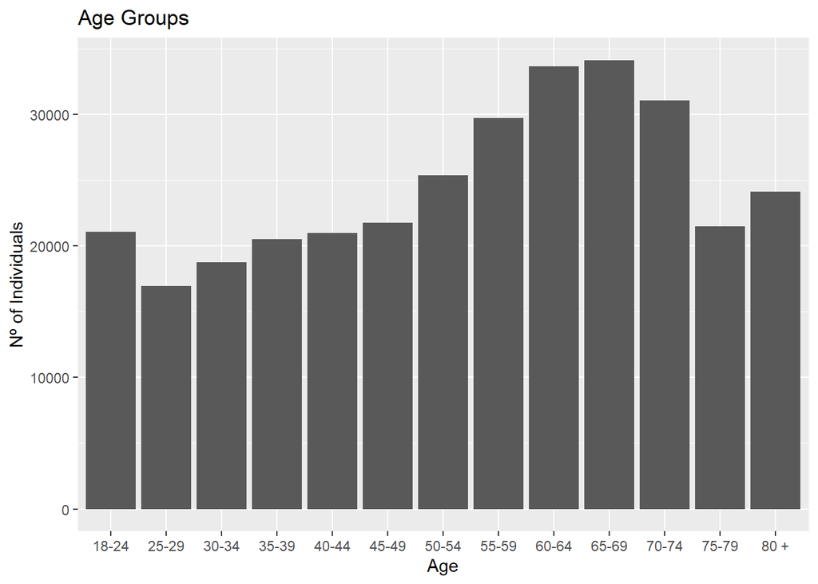

```r
heart_count_age <- heart %>%
  count(Age, name = 'count')

ggplot(heart_count_age) +
  geom_bar(aes(x = Age,
               y = count),
           stat = 'identity')+
  labs(title = "Age Groups", y = "Nº of Individuals")
```

## Explanatory Data Analysis

### Subset the Data

In order to start the analysis, there was a need to divide the data set in two parts was – one with the individuals that suffered from a heart disease and their characteristics and other with the ones who didn’t. This way, it is possible to compare the characteristics of persons who reported a heart disease with the characteristics of the ones who didn’t, and conclude if any of these factors has an impact in the development of a heart disease.

```r
heart_yes <- heart %>%
  filter(HeartDisease==1)

heart_no <- heart %>%
  filter(HeartDisease==0)
```

### Histogram’s sex

Male individuals reported a higher number of heart diseases (16139) than female individuals (11234). Additionally, females have a higher number of no heart disease reports (156571) than males (135851). Finally, as previously stated, this sample is composed by a higher number of females than males. These numbers altogether indicate that males have a higher probability of reporting a heart disease.

```r
heart_count_sex_yes <- heart_yes %>%
  count(Sex, name = 'count')
aggregate(count ~ Sex,data = heart_count_sex_yes,sum)
```

```
##      Sex count
## 1 Female 11234
## 2   Male 16139
```

[figure not shown]

```r
ggplot(heart_count_sex_yes) +
  geom_bar(aes(x = Sex,
               y = count),
           stat = 'identity',position = 'dodge')+
  labs(title = "Sex Groups with HeartDisease", y = "Nº of Individuals")
```

```r
heart_count_sex_no <- heart_no %>%
  count(Sex, name = 'count')
aggregate(count ~ Sex,data = heart_count_sex_no,sum)
```

```
##      Sex  count
## 1 Female 156571
## 2   Male 135851
```

[figure not shown]

```r
ggplot(heart_count_sex_no) +
  geom_bar(aes(x = Sex,
               y = count),
           stat = 'identity',position = 'dodge')+
  labs(title = "Sex Groups with no HeartDisease", y = "Nº of Individuals")
```

### Histogram Age

As previously stated, 91.4% individuals showed no signs of heart disease and 8.6% who did.

This indicates what was expected, older individuals have higher probability to develop a heart disease than younger ones.

```r
heart_count_age_no <- heart_no %>%
  count(Age, name = 'count')
sum(heart_count_age_no$count)
```

```
## [1] 292422
```

```r
heart_count_age_no
```

```
## # A tibble: 13 x 2
## # Groups:   Age [13]
##    Age   count
##    <chr> <int>
##  1 18-24 20934
##  2 25-29 16822
##  3 30-34 18527
##  4 35-39 20254
##  5 40-44 20520
##  6 45-49 21047
##  7 50-54 23999
##  8 55-59 27555
##  9 60-64 30359
## 10 65-69 30050
## 11 70-74 26218
## 12 75-79 17433
## 13 80 +  18704
```

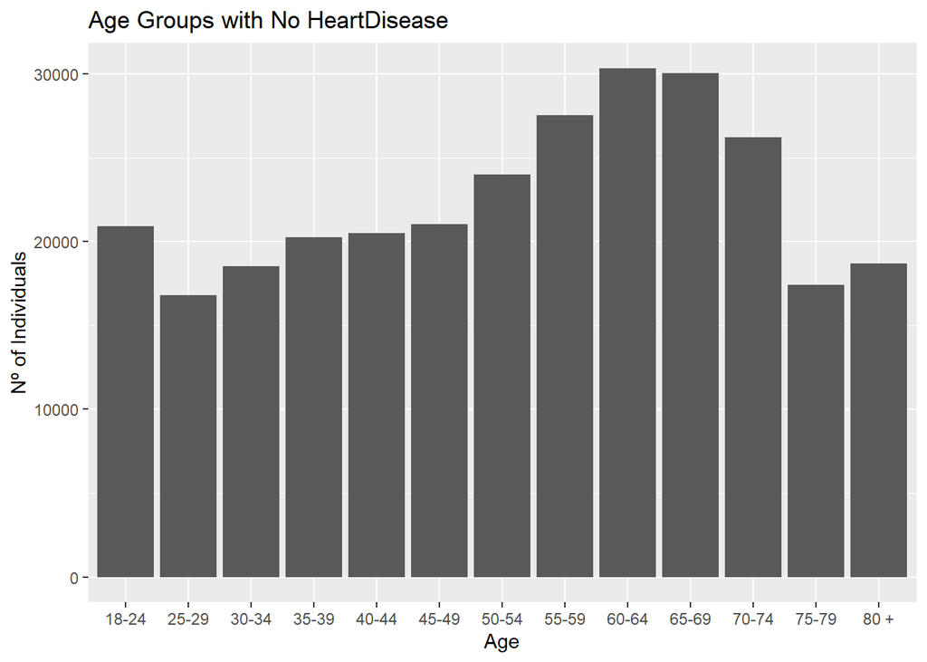

```r
ggplot(heart_count_age_no) +
  geom_bar(aes(x = Age,
               y = count),
           stat = 'identity')+
  labs(title = "Age Groups with No HeartDisease", y = "Nº of Individuals")
```

```r
heart_count_age_yes <- heart_yes %>%
  count(Age, name = 'count')
sum(heart_count_age_yes$count)
```

```
## [1] 27373
```

```r
heart_count_age_yes
```

```
## # A tibble: 13 x 2
## # Groups:   Age [13]
##    Age   count
##    <chr> <int>
##  1 18-24   130
##  2 25-29   133
##  3 30-34   226
##  4 35-39   296
##  5 40-44   486
##  6 45-49   744
##  7 50-54  1383
##  8 55-59  2202
##  9 60-64  3327
## 10 65-69  4101
## 11 70-74  4847
## 12 75-79  4049
## 13 80 +   5449
```

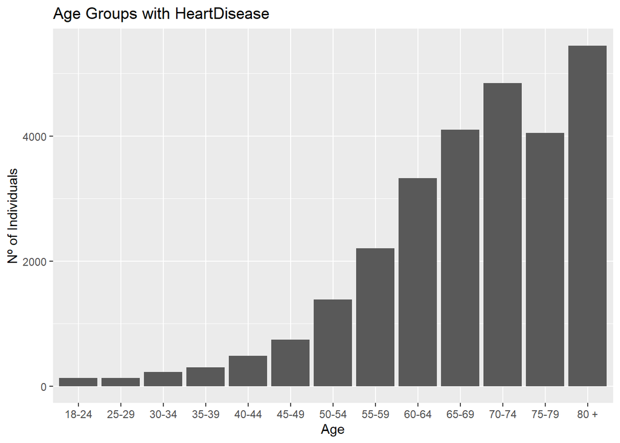

```r
ggplot(heart_count_age_yes) +
  geom_bar(aes(x = Age,
               y = count),
           stat = 'identity')+
  labs(title = "Age Groups with HeartDisease", y = "Nº of Individuals")
```

### Histogram Smoking

When looking at the data of individuals that **did** report a heart disease, it is perceivable that the majority of these individuals smoke (16037), as the non-smokers are only 11336. In addition, the higher number of **no** heart disease reports are from non-smokers (176551 > 115871). Thus, people who smoke have a higher probability of reporting a heart disease.

```r
heart_count_smoking_yes <- heart_yes %>%
  count(Smoking, name = 'count')
aggregate(count ~ Smoking,data = heart_count_smoking_yes,sum)
```

```
##   Smoking count
## 1       0 11336
## 2       1 16037
```

[figure not shown]

```r
ggplot(heart_count_smoking_yes) +
  geom_bar(aes(x = Smoking,
               y = count),
           stat = 'identity',position = 'dodge')+
  labs(title = "Smoking Groups with HeartDisease", y = "Nº of Individuals")
```

```r
heart_count_smoking_no <- heart_no %>%
  count(Smoking, name = 'count')
aggregate(count ~ Smoking,data = heart_count_smoking_no,sum)
```

```
##   Smoking  count
## 1       0 176551
## 2       1 115871
```

[figure not shown]

```r
ggplot(heart_count_smoking_no) +
  geom_bar(aes(x = Smoking,
               y = count),
           stat = 'identity',position = 'dodge')+
  labs(title = "Smoking Groups with No HeartDisease", y = "Nº of Individuals")
```

### Histogram Alcohol Drinking

The distributions of the alcohol drinking category are extremely different from what would be expected. It would be fair to say that alcohol could provoke, in the long run, heart diseases. However, according to the data set, there are more individuals who are **not** heavy drinkers that **did** report a heart disease (26232), than the ones who **are** heavy drinkers and **did** report a heart disease (1141). Furthermore, regarding the individuals that did **not** report a heart disease, the number of persons that are heavy drinkers rises to 20636. Thus, this sample shows no relation between drinking and reporting a heart disease.

```r
heart_count_alcohol_yes <- heart_yes %>%
  count(AlcoholDrinking, name = 'count')
aggregate(count ~ AlcoholDrinking,data = heart_count_alcohol_yes,sum)
```

```
##   AlcoholDrinking count
## 1               0 26232
## 2               1  1141
```

[figure not shown]

```r
ggplot(heart_count_alcohol_yes) +
  geom_bar(aes(x = AlcoholDrinking,
               y = count),
           stat = 'identity',position = 'dodge')+
  labs(title = "Alcohol Groups with HeartDisease", y = "Nº of Individuals")
```

```r
heart_count_alcohol_no <- heart_no %>%
  count(AlcoholDrinking, name = 'count')
aggregate(count ~ AlcoholDrinking,data = heart_count_alcohol_no,sum)
```

```
##   AlcoholDrinking  count
## 1               0 271786
## 2               1  20636
```

[figure not shown]

```r
ggplot(heart_count_alcohol_no) +
  geom_bar(aes(x = AlcoholDrinking,
               y = count),
           stat = 'identity',position = 'dodge')+
  labs(title = "Alcohol Groups with No HeartDisease", y = "Nº of Individuals")
```

### Histogram Physical Health

By observing the physical health distributions, there is a high probability that this characteristic affects the possibility of reporting a heart disease. 16.8% of people that **did** report a heart disease have indicated 30 days of bad physical health, whereas only 5% of people that did **not** report a heart disease indicated the same. Another key indicator that confirms the relevance of physical health is the fact that the mean of individuals who did not report a heart disease is of 2.956 days out of the last 30 with bad physical health. On the other hand, the mean of individuals who reported a heart disease is of 7.808 days of bad physical health.

```r
heart_count_Physical_yes <- heart_yes %>%
  count(PhysicalHealth, name = 'count')
aggregate(count ~ PhysicalHealth,data = heart_count_Physical_yes,sum)
```

```
##    PhysicalHealth count
## 1               0 14422
## 2               1   605
## 3               2  1169
## 4               3   843
## 5               4   494
## 6               5   896
## 7               6   173
## 8               7   465
## 9               8   120
## 10              9    37
## 11             10   838
## 12             11     9
## 13             12   104
## 14             13    10
```

[output cut: 17 more lines]

[figure not shown]

```r
ggplot(heart_count_Physical_yes) +
  geom_bar(aes(x = PhysicalHealth,
               y = count),
           stat = 'identity',position = 'dodge')+
  labs(title = "PhysicalHealth Groups with HeartDisease", y = "Nº of Individuals")
```

```r
heart_count_Physical_no <- heart_no %>%
  count(PhysicalHealth, name = 'count')
aggregate(count ~ PhysicalHealth,data = heart_count_Physical_no,sum)
```

```
##    PhysicalHealth  count
## 1               0 212167
## 2               1   9884
## 3               2  13711
## 4               3   7774
## 5               4   3974
## 6               5   6710
## 7               6   1097
## 8               7   4164
## 9               8    804
## 10              9    143
## 11             10   4615
## 12             11     76
## 13             12    501
## 14             13     81
```

[output cut: 17 more lines]

[figure not shown]

```r
ggplot(heart_count_Physical_no) +
  geom_bar(aes(x = PhysicalHealth,
               y = count),
           stat = 'identity',position = 'dodge')+
  labs(title = "PhysicalHealth Groups with No HeartDisease", y = "Nº of Individuals")
```

```r
summary(heart_yes$PhysicalHealth)
```

```
##    Min. 1st Qu.  Median    Mean 3rd Qu.    Max.
##   0.000   0.000   0.000   7.808  15.000  30.000
```

```r
summary(heart_no$PhysicalHealth)
```

```
##    Min. 1st Qu.  Median    Mean 3rd Qu.    Max.
##   0.000   0.000   0.000   2.956   1.000  30.000
```

### Histogram Mental Health

The distributions of mental health are very similar for individuals who did report a heart disease and for those who didn’t. The only extraordinary difference is that the mean of mental health for individuals who **did** report a heart disease is 4.642, a little higher than the one for **no** heart disease reports (3.829). This might indicate that mental health can affect the risk of heart disease, but not by a significant amount.

```r
heart_count_Mental_yes <- heart_yes %>%
  count(MentalHealth, name = 'count')
aggregate(count ~ MentalHealth,data = heart_count_Mental_yes,sum)
```

```
##    MentalHealth count
## 1             0 18215
## 2             1   613
## 3             2  1041
## 4             3   658
## 5             4   323
## 6             5   882
## 7             6   112
## 8             7   318
## 9             8    71
## 10            9    19
## 11           10   805
## 12           11    11
## 13           12    60
## 14           13     7
```

[output cut: 17 more lines]

[figure not shown]

```r
ggplot(heart_count_Mental_yes) +
  geom_bar(aes(x = MentalHealth,
               y = count),
           stat = 'identity',position = 'dodge')+
  labs(title = "MentalHealth Groups with HeartDisease", y = "Nº of Individuals")
```

```r
heart_count_Mental_no <- heart_no %>%
  count(MentalHealth, name = 'count')
aggregate(count ~ MentalHealth,data = heart_count_Mental_no,sum)
```

```
##    MentalHealth  count
## 1             0 187186
## 2             1   8678
## 3             2  15454
## 4             3   9808
## 5             4   5056
## 6             5  13267
## 7             6   1398
## 8             7   5210
## 9             8   1023
## 10            9    184
## 11           10   9708
## 12           11     72
## 13           12    697
## 14           13    103
```

[output cut: 17 more lines]

[figure not shown]

```r
ggplot(heart_count_Mental_no) +
  geom_bar(aes(x = MentalHealth,
               y = count),
           stat = 'identity',position = 'dodge')+
  labs(title = "MentalHealth Groups with No HeartDisease", y = "Nº of Individuals")
```

```r
summary(heart_yes$MentalHealth)
```

```
##    Min. 1st Qu.  Median    Mean 3rd Qu.    Max.
##   0.000   0.000   0.000   4.642   4.000  30.000
```

```r
summary(heart_no$MentalHealth)
```

```
##    Min. 1st Qu.  Median    Mean 3rd Qu.    Max.
##   0.000   0.000   0.000   3.829   3.000  30.000
```

### Histogram Sleep Time

The distributions of sleep time are also very similar for individuals who did report a heart disease and for those who didn’t. Even their means have very proximate values, where the mean of individuals that **did** report a heart disease is 7.136 and the mean for individuals that did **not** report a heart disease is of 7.093 hours. Some smaller differences arise when looking at both distributions simultaneous, given that individuals that have **not** reported a heart disease have an accentuated schedule of sleep between 6 and 8 hours of sleep, whereas persons that **did** report the existence of the disease sleep less or more than this schedule.

```r
heart_count_Sleep_yes <- heart_yes %>%
  count(SleepTime, name = 'count')
aggregate(count ~ SleepTime,data = heart_count_Sleep_yes,sum)
```

```
##    SleepTime count
## 1          1    60
## 2          2   128
## 3          3   347
## 4          4  1180
## 5          5  2030
## 6          6  5427
## 7          7  6325
## 8          8  8358
## 9          9  1696
## 10        10  1165
## 11        11    73
## 12        12   416
## 13        13    18
## 14        14    43
## 15        15    24
## 16        16    34
## 17        17     2
## 18        18    21
## 19        19     1
## 20        20    16
## 21        22     3
## 22        24     6
```

[figure not shown]

```r
ggplot(heart_count_Sleep_yes) +
  geom_bar(aes(x = SleepTime,
               y = count),
           stat = 'identity',position = 'dodge')+
  labs(title = "SleepTime Groups with HeartDisease", y = "Nº of Individuals")
```

```r
heart_count_Sleep_no <- heart_no %>%
  count(SleepTime, name = 'count')
aggregate(count ~ SleepTime,data = heart_count_Sleep_no,sum)
```

```
##    SleepTime count
## 1          1   491
## 2          2   660
## 3          3  1645
## 4          4  6570
## 5          5 17154
## 6          6 61294
## 7          7 91426
## 8          8 89244
## 9          9 14345
## 10        10  6631
## 11        11   342
## 12        12  1789
## 13        13    79
## 14        14   200
## 15        15   165
## 16        16   202
## 17        17    19
## 18        18    81
## 19        19     2
## 20        20    48
## 21        21     2
## 22        22     6
## 23        23     3
## 24        24    24
```

[figure not shown]

```r
ggplot(heart_count_Sleep_no) +
  geom_bar(aes(x = SleepTime,
               y = count),
           stat = 'identity',position = 'dodge')+
  labs(title = "MentalHealth Groups with No HeartDisease", y = "Nº of Individuals")
```

```r
summary(heart_yes$SleepTime)
```

```
##    Min. 1st Qu.  Median    Mean 3rd Qu.    Max.
##   1.000   6.000   7.000   7.136   8.000  24.000
```

```r
summary(heart_no$SleepTime)
```

```
##    Min. 1st Qu.  Median    Mean 3rd Qu.    Max.
##   1.000   6.000   7.000   7.093   8.000  24.000
```

### Correlations

Regarding the correlation matrix and plot we can observe what we previously stated when analyzing the individual distributions, which is that the two variables that have the highest positive influence on heart disease are physical health and smoking, where physical health is the one with highest correlation. Following these two characteristics is mental health which has very low correlation with the existence of a heart disease. Furthermore, as we suspected before, the alcohol consumption has a small, but negative correlation with heart disease, which indicates that there is a possibility that people who consume more alcohol have a higher chance of not having heart diseases. Lastly, sleep time has almost no correlation with the variable heart disease, which indicates that this characteristic might not have any influence on the appearance of a heart disease.

```r
heartdis <- heart$HeartDisease
smoking <- heart$Smoking
alcohol <- heart$AlcoholDrinking
physical <- heart$PhysicalHealth
mental <- heart$MentalHealth
sleep <- heart$SleepTime

cor(cbind(heartdis,smoking,alcohol,physical,mental,sleep))
```

```
##              heartdis     smoking      alcohol    physical      mental
## heartdis  1.000000000  0.10776416 -0.032079743  0.17072097  0.02859071
## smoking   0.107764156  1.00000000  0.111767520  0.11535241  0.08515729
## alcohol  -0.032079743  0.11176752  1.000000000 -0.01725429  0.05128197
## physical  0.170720972  0.11535241 -0.017254288  1.00000000  0.28798667
## mental    0.028590715  0.08515729  0.051281973  0.28798667  1.00000000
## sleep     0.008326647 -0.03033564 -0.005065451 -0.06138663 -0.11971679
##                 sleep
## heartdis  0.008326647
## smoking  -0.030335635
## alcohol  -0.005065451
## physical -0.061386632
## mental   -0.119716788
## sleep     1.000000000
```

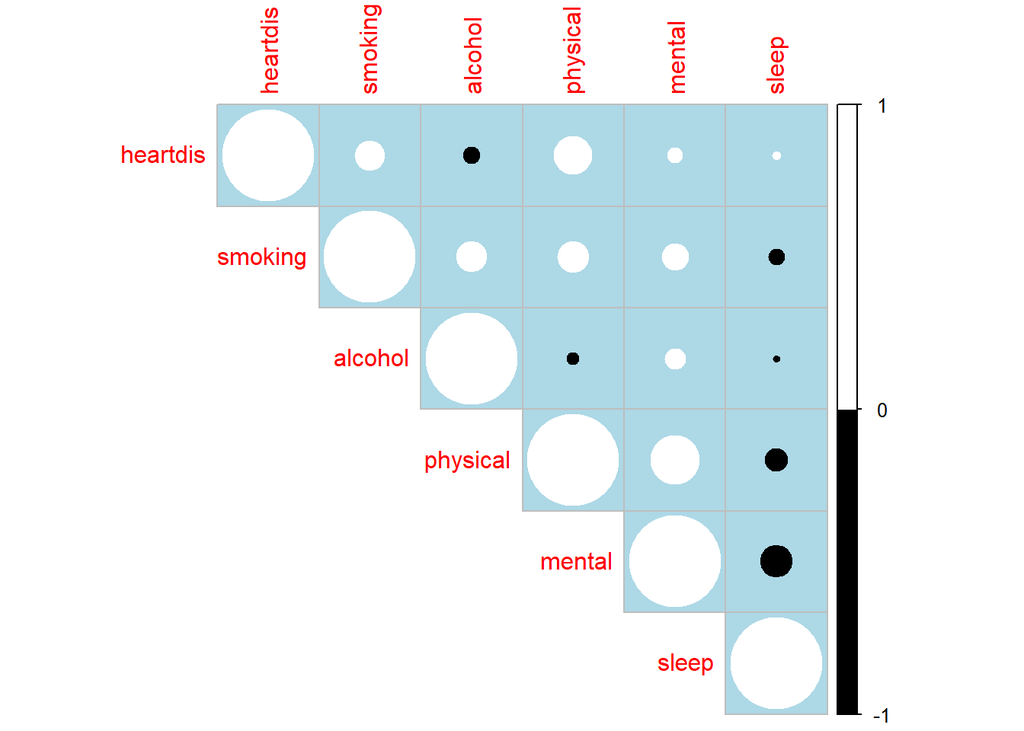

```r
corrplot(cor(cbind(heartdis,smoking,alcohol,physical,mental,sleep)),type = "upper",
         col=c("black", "white"),bg="lightblue")
```

## Interpretation / Conclusion

After an extensive explanatory analysis is now possible to summarize all the results and answer the research questions posed in the beggining of the project, but always considering that the results might not be accurate given the fact the sample is limited and homogeneous and correlation, one of the measures used in the explanatory analysis, is not causality. The answer to the first research question is that there is a significant difference in heart disease reports between males and females, whereas if you are a male individual you have a higher probability of having a heart disease rather than if you were a female. Considering the second research question, it is possible to confirm that older age groups (50 years old on wards) have a significant chance of reporting a heart disease than younger age groups (before 50 years old). Furthermore, it is also possible to conclude that individuals who smoke more than 100 cigarettes in their life time have a higher probability of having a heart disease. In contradiction, according to the explanatory data analysis, individuals who are considered heavy drinkers have less probability of reporting a heart disease. Although this conclusion came as a surprise, there is the possibility that the condition of being a heavy drinker is not well adjusted, which might justify the results from the explanatory analysis. Regarding the fifth research question, it is possible to conclude that individuals that have a bad physical health will have a higher probability of reporting a heart disease. This characteristic had the highest correlation with the heart disease variable. The same relationship is visible between mental health and the heart disease variable, whereas individuals that have a bad mental health will have a higher probability of reporting a heart disease. Lastly, to answer the final research question, we can conclude that sleeping patterns have almost no influence on reporting a heart disease.

## References

Pytlak, K. (2022, February 16). Personal key indicators of heart disease. Kaggle. Retrieved April 10, 2022, from https://www.kaggle.com/datasets/kamilpytlak/personal-key-indicators-of-heart-disease?datasetId=1936563&sortBy=voteCount

Nowbar, A. N., Gitto, M., Howard, J. P., Francis, D. P., & Al-Lamee, R. (2019). Mortality from ischemic heart disease. Circulation: Cardiovascular Quality and Outcomes, 12(6). https://doi.org/10.1161/circoutcomes.118.005375